# Imperfect serological test

```r
library(serosv)
library(ggplot2)
```

## Imperfect test

Function `correct_prevalence()` is used for estimating the true prevalence if the serological test used is imperfect

Arguments:

- `data` the input data frame, must either have:
  - `age`, `pos`, `tot` columns (for aggregated data)
  - **OR** `age`, `status` columns for (linelisting data)
- `bayesian` whether to adjust sero-prevalence using the Bayesian or frequentist approach. If set to `TRUE`, true sero-prevalence is estimated using MCMC.
- `init_se` sensitivity of the serological test (default value `0.95`)
- `init_sp` specificity of the serological test (default value `0.8`)
- `study_size_se` (applicable when `bayesian=TRUE`) sample size for sensitivity validation study (default value `1000`)
- `study_size_sp` (applicable when `bayesian=TRUE`) sample size for specificity validation study (default value `1000`)
- `chains` (applicable when `bayesian=TRUE`) number of Markov chains (default to `1`)
- `warmup` (applicable when `bayesian=TRUE`) number of warm up runs (default value `1000`)
- `iter` (applicable when `bayesian=TRUE`) number of iterations (default value `2000`)

The function will return a list of 2 items:

- `info`
  - if `bayesian = TRUE` contains estimated values for se, sp and corrected seroprevalence
  - else return the formula for computing corrected seroprevalence
- `corrected_sero` return a data.frame with `age`, `sero` (corrected sero) and `pos`, `tot` (adjusted based on corrected prevalence)

```r
# ---- estimate real prevalence using Bayesian approach ----
data <- rubella_uk_1986_1987
output <- correct_prevalence(data, warmup = 1000, iter = 4000, init_se=0.9, init_sp = 0.8, study_size_se=1000, study_size_sp=3000)
# check fitted value
output$info[1:2, ]
```

```
#>             mean      se_mean          sd      2.5%       25%       50%
#> est_se 0.9276088 0.0001003224 0.005998519 0.9157822 0.9236570 0.9276923
#> est_sp 0.8027202 0.0001009184 0.006876397 0.7887838 0.7981318 0.8028880
#>              75%     97.5%    n_eff      Rhat
#> est_se 0.9316999 0.9391490 3575.135 0.9997911
#> est_sp 0.8074489 0.8156825 4642.808 0.9997088
```

```r
# ---- estimate real prevalence using frequentist approach ----
freq_output <- correct_prevalence(data, bayesian = FALSE, init_se=0.9, init_sp = 0.8)

# check info
freq_output$info
```

```
#> [1] "Formula: real_sero = (apparent_sero + sp - 1) / (se + sp -1)"
```

[figure not shown]

```r
# compare original prevalence and corrected prevalence
ggplot()+
  geom_point(aes(x = data$age, y = data$pos/data$tot, color="apparent prevalence")) +
  geom_point(aes(x = output$corrected_se$age, y = output$corrected_se$sero, color="estimated prevalence (bayesian)" )) +
  geom_point(aes(x = freq_output$corrected_se$age, y = freq_output$corrected_se$sero, color="estimated prevalence (frequentist)" )) +
  scale_color_manual(
    values = c(
      "apparent prevalence" = "red",
      "estimated prevalence (bayesian)" = "blueviolet",
      "estimated prevalence (frequentist)" = "royalblue")
  )+
  labs(x = "Age", y = "Prevalence")
```

### Fitting corrected data

**Data after seroprevalence correction**

Bayesian approach

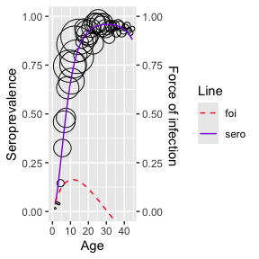

```r
suppressWarnings(
  corrected_data <- farrington_model(
  output$corrected_se,
  start=list(alpha=0.07,beta=0.1,gamma=0.03))
)

plot(corrected_data)
```

Frequentist approach

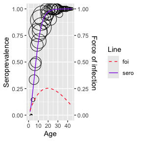

```r
suppressWarnings(
  corrected_data <- farrington_model(
  freq_output$corrected_se,
  start=list(alpha=0.07,beta=0.1,gamma=0.03))
)

plot(corrected_data)
```

**Original data**

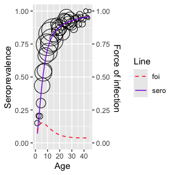

```r
suppressWarnings(
  original_data <- farrington_model(
  data,
  start=list(alpha=0.07,beta=0.1,gamma=0.03))
)
plot(original_data)
```